# Mecanismo de selección de la estructura espacial y sus aplicaciones

Mabel Salazar

2025-07-05

# 1 Carga de Base de datos

```r
base_sylvatica <- readxl::read_excel("Base de datos completa Sylvatica con correcciones localidad.xlsx")
base_dentrobatidos <- read_excel("Base dentrobatidos MEPN (1).xlsx", range = "A1:AJ768")
base_dietas_ranas <- read_excel("Dietas_Ranas_Proyectos_DD.xlsx")
```

# 2 Gráficas de agrupación en décadas y 20 años

```r
#### Comprovar que columnas existen
colnames(base_dietas_ranas)
```

```
##  [1] "Fecha"                 "Longitud"              "Latitud"
##  [4] "Especie"               "Abundancia"            "Género"
##  [7] "Tamaño"                "Temperatura (°C)"      "Evotranspiración (mm)"
## [10] "Humedad"               "Precipitación (mm)"    "Elevación (m)"
## [13] "Proyecto"
```

```r
colnames(base_sylvatica)
```

```
##  [1] "Número de colección" "Año de la colección" "Mes de colección"
##  [4] "Provincia"           "Cantón"              "Parroquia"
##  [7] "Localidad"           "Latitud"             "Longitud"
## [10] "Altitud"             "Sexo"                "Estadío"
## [13] "Observaciones"
```

```r
colnames(base_dentrobatidos)
```

```
##  [1] "Nº CATÁLOGO"
##  [2] "CLASE"
##  [3] "ORDEN"
##  [4] "FAMILIA"
##  [5] "SUBFAMILIA"
##  [6] "GENERO"
##  [7] "ESPECIE"
##  [8] "DETERMINADO POR"
##  [9] "Nº DE CAMPO"
## [10] "FECHA DE COLECCIÓN"
## [11] "mes"
## [12] "AÑO"
## [13] "CONTINENTE"
## [14] "PAIS"
## [15] "PROVINCIA"
```

[output cut: 21 more lines]

```r
### Convierto las coordenadas para la creación de los gráficos
coordenadas <- function(coordenada) {
  if (!is.na(coordenada) && grepl("W|S|E|N", coordenada)) {
    valor <- as.numeric(gsub("[^0-9\\.]", "", coordenada))
    if (grepl("W|S", coordenada)) {
      return(-valor)
    } else {
      return(valor)
    }
  } else {
    return(as.numeric(coordenada))
  }
}

# Convierto AÑO a numérico
base_dentrobatidos <- base_dentrobatidos %>%
  filter(PAIS == "Ecuador") %>%
  mutate(
    numero_col = paste0("MEPN_", `Nº CATÁLOGO`),  # Crear una columna 'numero_col'
    AÑO = as.numeric(AÑO)  # Convertir AÑO a numérico
  )

# Convierto Año de la colección a númerico
base_sylvatica <- base_sylvatica %>%
  filter(!is.na(Latitud) & !is.na(Longitud) & Latitud != "-" & Longitud != "-") %>%
  mutate(
    Latitud = as.numeric(Latitud),
    Longitud = as.numeric(Longitud),
    `Año de la colección` = as.numeric(`Año de la colección`),
    Altitud = as.numeric(Altitud)
  )


##Aplicamos la funcion de conversión de coordenadas en latitud y longitud a la base dietas ranas
base_dietas_ranas <- base_dietas_ranas %>%
  mutate(Longitud = sapply(Longitud, coordenadas),
         Latitud = sapply(Latitud, coordenadas)) %>%
  filter(!is.na(Fecha)) %>%
  mutate(Fecha = as.Date(Fecha, format = "%Y-%m-%d"),
         `Año de la colección` = year(Fecha),
         `Mes de colección` = month(Fecha, label = TRUE, abbr = FALSE)) %>%
  select(`Año de la colección`, `Mes de colección`, Longitud, Latitud, `Elevación (m)`, Especie)

####------------------------------------------------------------------------------------------------------

# Estandarizamos y limpiamos la base para que existan coincidencias con las columnas de otras bases

dietas_ranas_estandarizada <- base_dietas_ranas %>%
  mutate(numero_col = "Indeterminado",
         `COORD DECIMALES  LATITUD` = Latitud,
         `COORD DECIMALES  LONGITUD` = Longitud,
         `ALTITUD msnm` = `Elevación (m)`,
         ESPECIE = Especie,
         AÑO = `Año de la colección`,
         mes = `Mes de colección`) %>%
  select(numero_col, ESPECIE, AÑO, mes, `COORD DECIMALES  LATITUD`, `COORD DECIMALES  LONGITUD`, `ALTITUD msnm`)


base_sylvatica <- base_sylvatica %>%
  mutate(
    mes = tolower(`Mes de colección`),
    mes = as.numeric(factor(mes, levels = c("enero", "febrero", "marzo", "abril", "mayo", "junio",
                                            "julio", "agosto", "septiembre", "octubre", "noviembre", "diciembre"))),
    `ALTITUD msnm` = as.numeric(Altitud)  # Convertir Altitud a numérico
  ) %>%
  rename(numero_col = `Número de colección`,
         AÑO = `Año de la colección`,
         `COORD DECIMALES  LONGITUD` = Longitud,
         `COORD DECIMALES  LATITUD` = Latitud)

#-------------------------------------------------------------------------------------------------------------

## Tranformación de la columna mes a númerico
dietas_ranas_estandarizada <- dietas_ranas_estandarizada %>%
  mutate(mes = as.numeric(mes))


#### Transformacion al formato correcto para que realize la compatibilidad con las otras columnas
### de las otras bases
base_dentrobatidos <- base_dentrobatidos %>%
  mutate(mes = as.numeric(mes),
         `ALTITUD msnm` = as.numeric(`ALTITUD msnm`)) %>%
  select(numero_col, ESPECIE, AÑO, mes, `COORD DECIMALES  LATITUD`, `COORD DECIMALES  LONGITUD`, `ALTITUD msnm`)



base_final <- bind_rows(base_sylvatica, base_dentrobatidos, dietas_ranas_estandarizada) %>%
  mutate(`COORD DECIMALES  LONGITUD` = ifelse(`COORD DECIMALES  LONGITUD` > 0,
                                              -`COORD DECIMALES  LONGITUD`,
                                              `COORD DECIMALES  LONGITUD`)) %>%
  filter(`COORD DECIMALES  LATITUD` >= -5 & `COORD DECIMALES  LATITUD` <= 2,
         `COORD DECIMALES  LONGITUD` >= -81 & `COORD DECIMALES  LONGITUD` <= -75)


# Creamos los intervalos para la distribución de los datos por decada y cada 20 años
base_final <- base_final %>%
  mutate(
    # Intervalo cada 20 años
    periodo_20 = cut(AÑO,
                           breaks = c(1950, 1969, 1989, 2009, 2019),  # Definir correctamente los cortes de 20 años
                           labels = c("1950-1969", "1970-1989", "1990-2009", "2010-2019"),
                           right = FALSE),  # Para incluir el año inicial y excluir el final

    # Intervalo cada 10 años
    periodo_decadas = cut(AÑO,
                          breaks = c(1950, 1960, 1970, 1980, 1990, 2000, 2010, 2020),  # Cortes para décadas
                          labels = c("1950-1959", "1960-1969", "1970-1979", "1980-1989",
                                     "1990-1999", "2000-2009", "2010-2019"),
                          right = FALSE)  # Incluir el año inicial, excluir el final
  )

#Revisamos si la base final esta bien distribuida por década y cada 20 años

summary(base_final$periodo_20)
```

```
## 1950-1969 1970-1989 1990-2009 2010-2019      NA's
##        29       316       661       514       130
```

```r
summary(base_final$periodo_decadas)
```

```
## 1950-1959 1960-1969 1970-1979 1980-1989 1990-1999 2000-2009 2010-2019      NA's
##        14        15        26       298       244       645       356        52
```

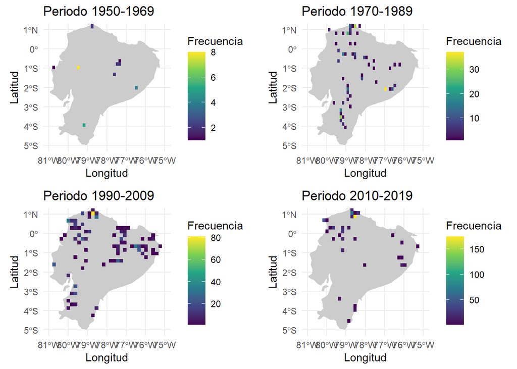

```r
# Obtener mapa de Ecuador
mapa_ecuador <- ne_countries(scale = "medium", country = "Ecuador", returnclass = "sf")

#-------------------------------CREACION DE GRAFICOS

crear_grafico_periodo <- function(data, title) {
  ggplot() +
    geom_sf(data = mapa_ecuador, fill = "gray80", color = "white") +
    stat_bin2d(data = data,
               aes(x = `COORD DECIMALES  LONGITUD`, y = `COORD DECIMALES  LATITUD`, fill = ..count..),
               bins = 30) +
    scale_fill_viridis_c(option = "viridis", name = "Frecuencia") +
    labs(title = title, x = "Longitud", y = "Latitud") +
    theme_minimal() +
    coord_sf(xlim = c(-81, -75), ylim = c(-5, 1))
}

crear_graficos_periodo <- function(data, periodo_col, title_prefix) {
  periodos <- levels(data[[periodo_col]])
  plots <- lapply(periodos, function(periodo) {
    data_periodo <- data %>% filter(!!sym(periodo_col) == periodo)
    if (nrow(data_periodo) > 0) {
      crear_grafico_periodo(data_periodo, paste(title_prefix, periodo))
    }
  })


  # Filtrar gráficos que no tengan datos NULL
  plots <- Filter(Negate(is.null), plots)

  num_plots <- length(plots)
  if (num_plots == 4) {
    do.call(grid.arrange, c(plots, nrow = 2, ncol = 2))
  }
  else if (num_plots > 4) {
    num_cols <- ceiling(sqrt(num_plots))
    num_rows <- ceiling(num_plots / num_cols)
    do.call(grid.arrange, c(plots, nrow = num_rows, ncol = num_cols))
  }
}
#### Creación de gráficos cada 20 años
crear_graficos_periodo(base_final, "periodo_20", "Periodo")
```

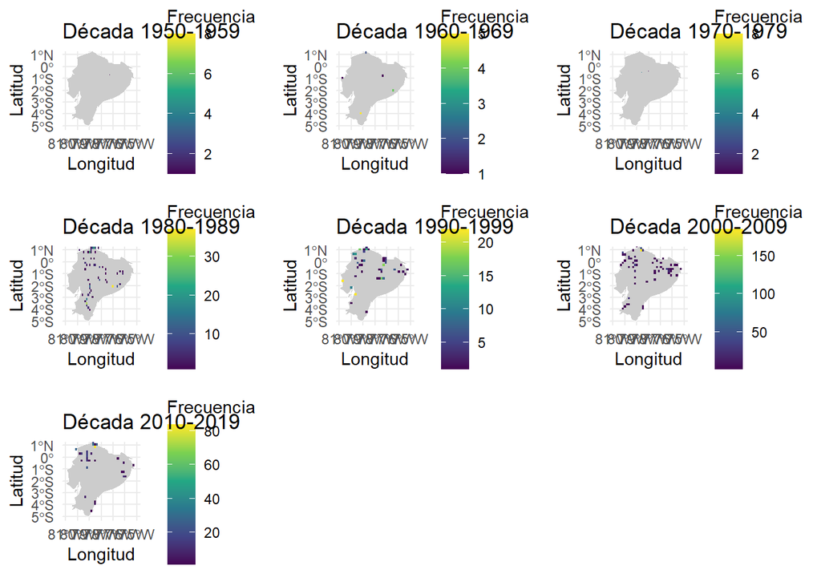

```r
###$ Creación de gráficos cada 10 años
crear_graficos_periodo(base_final, "periodo_decadas", "Década")
```

```r
### Muestra de la distribuciones de los datos

tabla_periodo_20 <- base_final %>%
  group_by(periodo_20) %>%
  summarise(Conteo = n()) %>%
  mutate(Tipo = "Periodo de 20 años")

tabla_periodo_20
```

```
## # A tibble: 5 × 3
##   periodo_20 Conteo Tipo
##   <fct>       <int> <chr>
## 1 1950-1969      29 Periodo de 20 años
## 2 1970-1989     316 Periodo de 20 años
## 3 1990-2009     661 Periodo de 20 años
## 4 2010-2019     514 Periodo de 20 años
## 5 <NA>          130 Periodo de 20 años
```

```r
tabla_periodo_decadas <- base_final %>%
  group_by(periodo_decadas) %>%
  summarise(Conteo = n()) %>%
  mutate(Tipo = "Décadas")

tabla_periodo_decadas
```

```
## # A tibble: 8 × 3
##   periodo_decadas Conteo Tipo
##   <fct>            <int> <chr>
## 1 1950-1959           14 Décadas
## 2 1960-1969           15 Décadas
## 3 1970-1979           26 Décadas
## 4 1980-1989          298 Décadas
## 5 1990-1999          244 Décadas
## 6 2000-2009          645 Décadas
## 7 2010-2019          356 Décadas
## 8 <NA>                52 Décadas
```

# 3 Intensidad y distribución espacio temporal

```r
source("Codigos_extras.R")
#------------------------
datos_frecuencia <- base_final %>%
  group_by(`COORD DECIMALES  LONGITUD`,`COORD DECIMALES  LATITUD`, periodo_decadas) %>%
filter(!is.na(periodo_decadas)) %>% mutate(periodo_decadas=as.numeric(periodo_decadas))

ecuador_sf <- ne_countries(scale = "medium", country = "Ecuador", returnclass = "sf")
ecuador_continental <- ecuador_sf %>%
  st_crop(xmin = -81, xmax = -75, ymin = -5, ymax = 2)

ecuador_proj <- st_transform(ecuador_continental, crs = 32717)
ecuador_owin <- as.owin(ecuador_proj)
colnames(datos_frecuencia) <- trimws(colnames(datos_frecuencia))

any(grepl("LONGITUD", colnames(datos_frecuencia)))
```

```
## [1] TRUE
```

```r
any(grepl("LATITUD", colnames(datos_frecuencia)))
```

```
## [1] TRUE
```

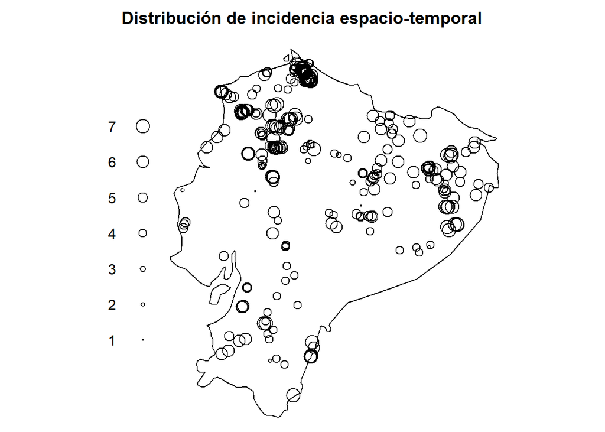

```r
colnames(datos_frecuencia) <- gsub("\\s+", " ", colnames(datos_frecuencia))  # Reemplaza múltiples espacios por uno solo
colnames(datos_frecuencia) <- trimws(colnames(datos_frecuencia))  # Elimina espacios al inicio y fin

base_sf <- st_as_sf(datos_frecuencia,
                    coords = c("COORD DECIMALES LONGITUD", "COORD DECIMALES LATITUD"),
                    crs = 4326)

base_proj <- st_transform(base_sf, crs = 32717)

coords_proj <- st_coordinates(base_proj)

spatial_data <- ppp(coords_proj[,1], coords_proj[,2], window = ecuador_owin, marks = datos_frecuencia$periodo_decadas)

puntos_dentro <- inside.owin(spatial_data$x, spatial_data$y, ecuador_owin)

spatial_data<- spatial_data[puntos_dentro]



par(mar=c(0,0,2,0))


plot(spatial_data, main="Distribución de incidencia espacio-temporal")
```

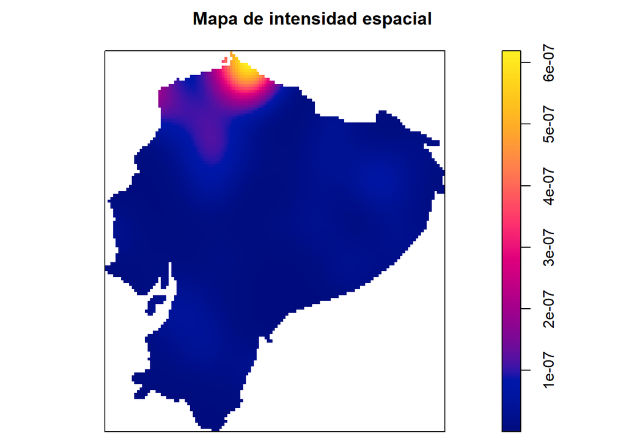

```r
# Optimización del suavizamiento espacial
sigma.s <- bw.scott(spatial_data)  # Estimación automática de suavizamiento espacial
sigma.t <- bw.scott(as.ppp(data.frame(x=spatial_data$marks, y=rep(1, length(spatial_data$marks))), c(0, max(spatial_data$marks), 0, 2)))

# Calcular la intensidad espacial con un estimador de Kernel
spatial_density <- density.ppp(spatial_data, sigma=sigma.s[1], eps = c(5000, 5000))

densidad <- density(spatial_data, weights = marks(spatial_data), sigma = sigma.s[1])

# Graficar el mapa de calor
plot(densidad, main = "Mapa de intensidad espacial")
```

- Existen concentraciones espaciales claras de registros en ciertas zonas como el norte y centro de la región andina.
- En etapas tempranas (círculos pequeños), los registros se concentran en regiones particulares, mientras que en décadas más recientes (círculos grandes), los registros se expanden hacia otras regiones del país.
- Esta variación en la localización espacial a lo largo del tiempo sugiere una posible dependencia entre espacio y tiempo.

La escala de colores representa la magnitud de la intensidad:

- Azul oscuro: baja intensidad.
- Rosado y amarillo: alta intensidad.

El resto del país, incluyendo la Sierra central, el sur andino y el sur amazónico, presenta intensidades mucho más bajas.

# 4 Envolventes

```r
### Espacila data para el analisis en periodos

datos_frecuencia1 <- base_final %>%
  group_by(`COORD DECIMALES  LONGITUD`,`COORD DECIMALES  LATITUD`, AÑO) %>%
filter(!is.na(AÑO)) %>% mutate(AÑO=as.numeric(AÑO))

colnames(datos_frecuencia1) <- trimws(colnames(datos_frecuencia1))

any(grepl("LONGITUD", colnames(datos_frecuencia1)))
```

```
## [1] TRUE
```

```r
any(grepl("LATITUD", colnames(datos_frecuencia1)))
```

```
## [1] TRUE
```

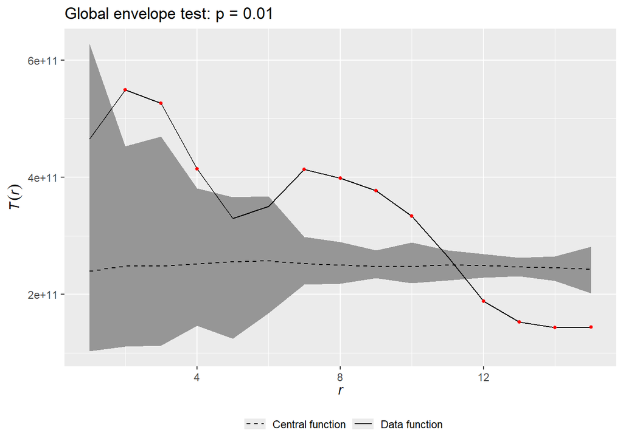

```r
colnames(datos_frecuencia1) <- gsub("\\s+", " ", colnames(datos_frecuencia1))  # Reemplaza múltiples espacios por uno solo
colnames(datos_frecuencia1) <- trimws(colnames(datos_frecuencia1))  # Elimina espacios al inicio y fin

base_sf1 <- st_as_sf(datos_frecuencia1,
                    coords = c("COORD DECIMALES LONGITUD", "COORD DECIMALES LATITUD"),
                    crs = 4326)

base_proj1 <- st_transform(base_sf1, crs = 32717)

coords_proj1 <- st_coordinates(base_proj1)

spatial_data1 <- ppp(coords_proj1[,1], coords_proj1[,2], window = ecuador_owin, marks = datos_frecuencia1$AÑO)

puntos_dentro1 <- inside.owin(spatial_data1$x, spatial_data1$y, ecuador_owin)

spatial_data1 <- spatial_data1[puntos_dentro1]

sigma.s1 <- bw.scott(spatial_data1)  # Estimación automática de suavizamiento espacial
sigma.t1 <- bw.scott(as.ppp(data.frame(x=spatial_data1$marks, y=rep(1, length(spatial_data1$marks))), c(0, max(spatial_data1$marks), 0, 2)))

# Crear la secuencia de tiempos automáticamente
times <- seq(from = min(spatial_data1$marks),
             to = max(spatial_data1$marks),
             length.out = 15)
# Resolución de la grilla ajustada según la dispersión espacial de los datos
dimyx <- c(59, 64)
# Número de permutaciones (usar 999 para resultados más robustos)
n.perm <- 99
# Crear patrones permutados en el tiempo
perm.list <- permute.times(spatial_data1, n=n.perm)

# Lista para almacenar los resultados de cada permutación
res.list <- list()
# Calcular la estadística S, S.space y S.time para cada permutación
for (i in 1:(n.perm+1)){
  res.list[[i]] <- S.stats(perm.list[[i]], sigma.t=sigma.t1[1], sigma.s=sigma.s1[1] , dimyx=dimyx,
                           times=times, start.time=min(spatial_data1$marks),
                           end.time=max(spatial_data1$marks))
}
# ============================================
# Envolvente Global para S.time (en el tiempo)
# ============================================
dim.t <- length(times)
allstats <- array(dim=c(dim.t, n.perm+1))
for (i in 1:(n.perm+1)){
  allstats[,i] <- res.list[[i]]$S.time
}
cs <- create_curve_set(list(obs=allstats[,1], sim_m=allstats[,2:(n.perm+1)]))
S.time.GET <- global_envelope_test(cs)
# Graficar el resultado del test
plot(S.time.GET, main="Envolvente Global para S.time")
```

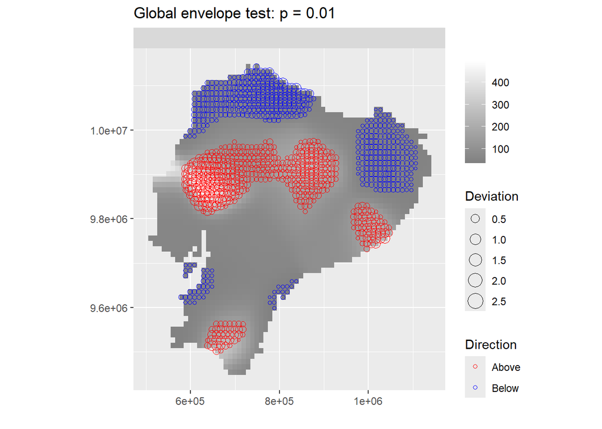

```r
# ============================================
# Envolvente Global para S.space (en el espacio)
# ============================================
aux.dim <- length(res.list[[1]]$S.space)
allstats <- array(dim=c(aux.dim, n.perm+1))
for (i in 1:(n.perm+1)){
  allstats[,i] <- res.list[[i]]$S.space
}
cs <- create_curve_set(list(r=data.frame(res.list[[1]]$coordinates.2D,
                                         width=res.list[[1]]$width, height=res.list[[1]]$height),
                            obs=allstats[,1], sim_m=allstats[,2:(n.perm+1)]))
S.space.GET <- global_envelope_test(cs)
# Graficar el resultado del test en espacio
plot(S.space.GET, main="Envolvente Global para S.space")
```

```r
# ============================================
# Envolvente Global para S (total)
# ============================================
aux.dim <- length(res.list[[1]]$S)
allstats <- array(dim=c(aux.dim, n.perm+1))
for (i in 1:(n.perm+1)){
  allstats[,i] <- res.list[[i]]$S
}
cs <- create_curve_set(list(obs=allstats[,1], sim_m=allstats[,2:(n.perm+1)]))
S.GET <- global_envelope_test(cs)
# Mostrar p-valor del test
p_value <- attr(S.GET, "p")
print(paste("P-valor del test global S:", p_value))
```

```
## [1] "P-valor del test global S: 0.01"
```

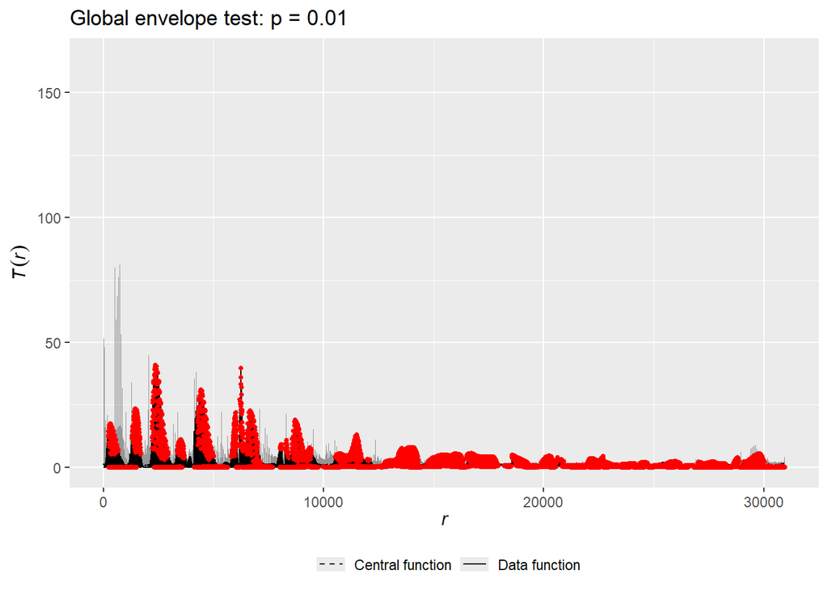

```r
# Graficar el resultado de la envolvente global para S
plot(S.GET, main="Envolvente Global para S")
```

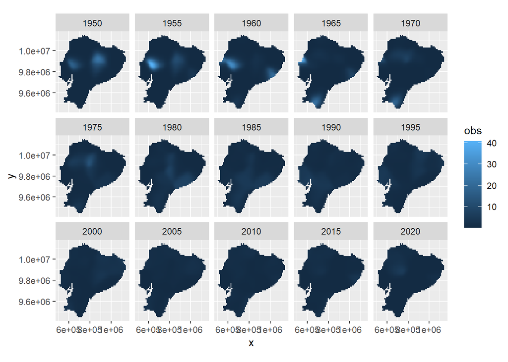

```r
# ============================================
# Graficar las funciones observadas y los límites de la envolvente
# ============================================
plot.global_envelope.3D(S.GET=S.GET, coordinates.3D=res.list[[1]]$coordinates.3D, what="obs")
```

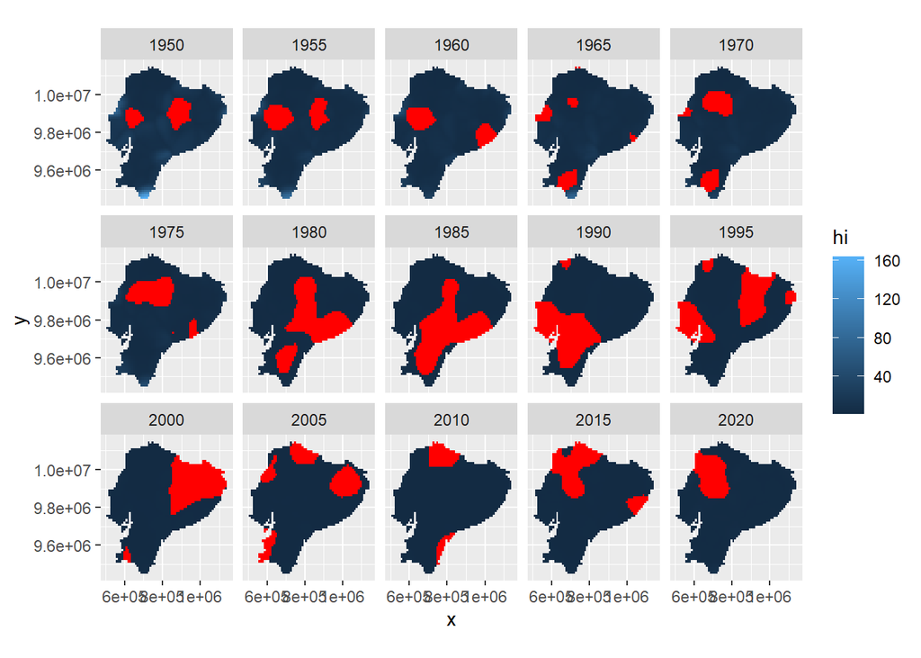

```r
plot.global_envelope.3D(S.GET=S.GET, coordinates.3D=res.list[[1]]$coordinates.3D, what="hi")
```

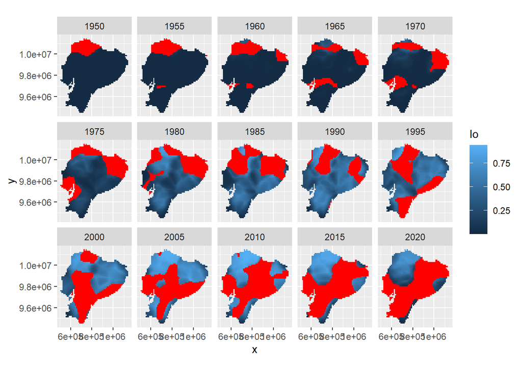

```r
plot.global_envelope.3D(S.GET=S.GET, coordinates.3D=res.list[[1]]$coordinates.3D, what="lo")
```

```r
save(spatial_data1,sigma.s1,sigma.t1,file = "objetos_shiny.RData")
```

**Intensidad Temporal**

Hay periodos específicos donde el patrón espacio-temporal se desvía significativamente del modelo nulo. Esto confirma que no hay independencia entre cuándo y dónde ocurre la presencia de la especie.

**Intensidad Espacial**

Las áreas rojas y azules indican zonas donde la intensidad espacial cambia significativamente con el tiempo. Se observan focos no aleatorios de actividad, como en el centro-norte y sur del país, lo cual refuerza la evidencia de estructura espacio-temporal dependiente.

**Intensidad Espacio Temporal**

Se observa que la función test sale de la envolvente muchas veces a lo largo del rango de distancias, lo cual indica que la intensidad del patrón observado no puede explicarse solo por separabilidad. La dependencia espacio-temporal está presente en múltiples escalas.

**Gráficas de las funciones observadas y los límites de la envolvente**

**Gráfica Obs**

- Se observa que las zonas de concentración de observaciones cambian con el tiempo.

**Grafica hi**

Este panel marca en rojo las regiones donde la intensidad observada es mayor de lo esperado bajo la hipótesis nula de separabilidad.

Estas zonas cambian en cada periodo, apareciendo en diferentes partes del país.

Esto indica que las zonas de alta intensidad no son constantes a lo largo del tiempo, lo cual viola la suposición de separabilidad espacio-temporal.

**Grafica lo**

Este panel muestra en rojo las regiones donde la intensidad observada es menor de lo esperado.

- Esto evidencia una reconfiguración del patrón espacial a lo largo del tiempo.

Estas zonas de baja intensidad que varían también refuerzan la idea de dependencia entre espacio y tiempo.

# 5 Reconstrucción estocastica

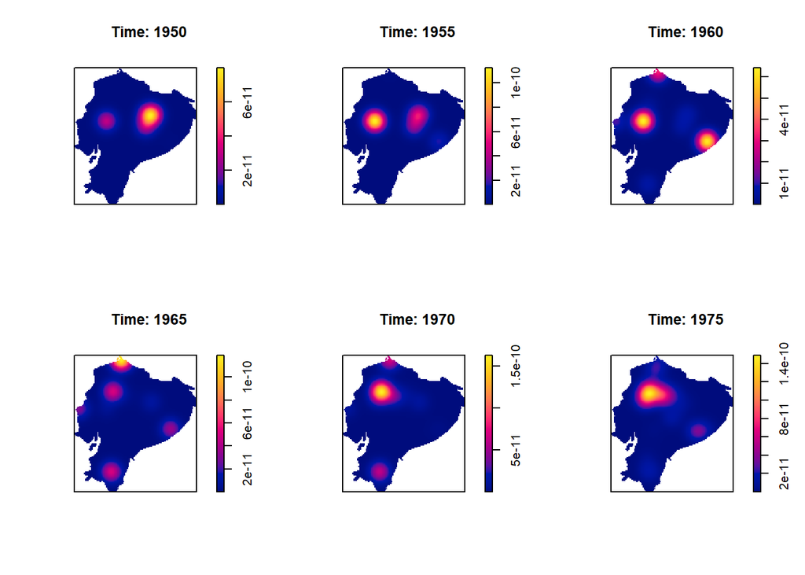

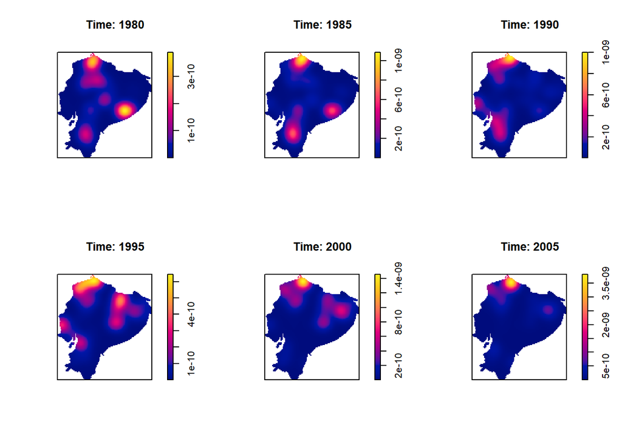

```r
intensity_est <- intensityST.nonsep.grid(spatial_data1, sigma.s = sigma.s1[1], sigma.t = sigma.t1[1], times = times , start.time=min(spatial_data1$marks),end.time=max(spatial_data1$marks))

intensity_points <- intensityST.nonsep.points(spatial_data1, sigma.s = sigma.s1[1], sigma.t = sigma.t1[1], start.time=min(spatial_data1$marks),end.time=max(spatial_data1$marks))

# Graficar las imágenes para cada tiempo
par(mfrow = c(2, 3))  # Organiza las imágenes en una cuadrícula de 2x2
for(i in 1:length(intensity_est)) {
  plot(intensity_est[[i]], main = paste("Time:", times[i]))
}
```

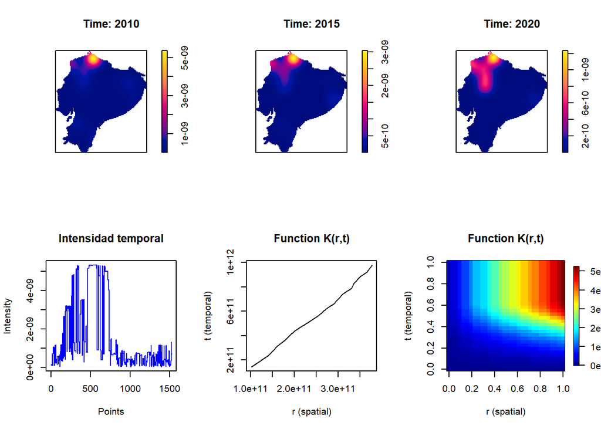

```r
# Graficar la intensidad en los puntos
plot(intensity_points, type = "l", col = "blue",
     xlab = "Points", ylab = "Intensity",
     main = "Intensidad temporal")



Tmax <- 20 #
# Calcular la función K(r,t)
K_function <- Krt(X = spatial_data1, lambda = intensity_points,
                  Rmax = 1000000, Tmax = Tmax, grid = 32,
                  start.time = min(spatial_data1$marks),
                  end.time = max(spatial_data1$marks))

# Graficar la función K(r,t)
# Aquí usaremos image para una visualización más completa de la superficie.
plot(K_function, type= 'l', main = "Function K(r,t)", xlab = "r (spatial)", ylab = "t (temporal)")
image.plot(K_function, main = "Function K(r,t)", xlab = "r (spatial)", ylab = "t (temporal)")
```

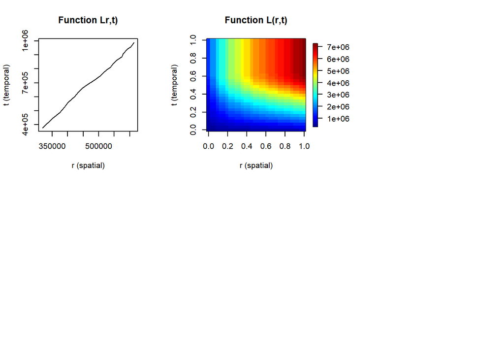

```
## Estimating summary characteristics of the input pattern.
## Generating the initial configuration.
##
## Maximum number of iterations: 500. Maximum number of rejected proposals in a row: 200.
## Starting iterations, the ''+'' symbol indicates accepted proposal, the  ''.'' symbol indicates rejected proposal.
##
## ++......+.....++...+.+..++.+......+.+...+.....++...+.+.+......+..+......++.......++++.++..+++++.+.+.(finished 100 iterations so far)
```

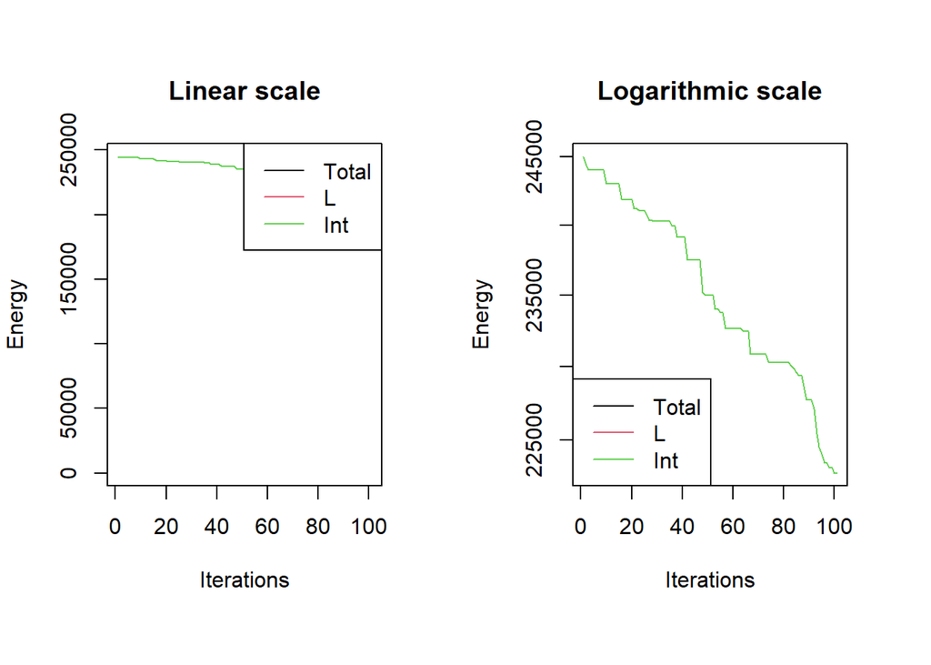

```
## .+..++..+.++.++...+.+..+.++.....++.+.++...+.++......++++....+++..+..+.+++++..+.+....+.+..+.+.++.+...(finished 200 iterations so far)
```

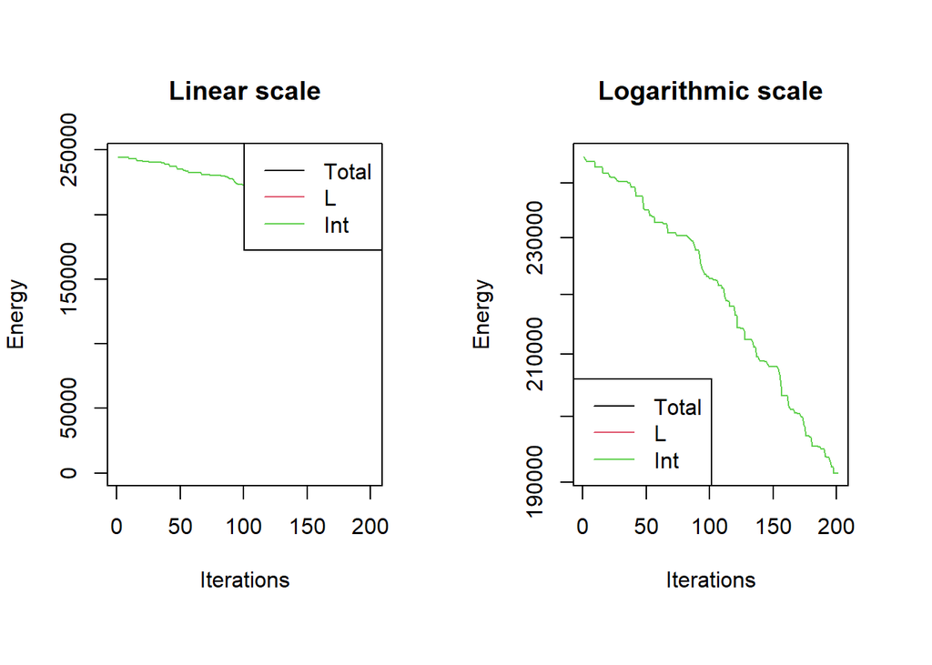

```
## +.+......+..++.++....+.+.+.+.+++.+++.+...+++...+.+.+..+..+....+...++++.+.+.++.+..+++....+..++....++.(finished 300 iterations so far)
```

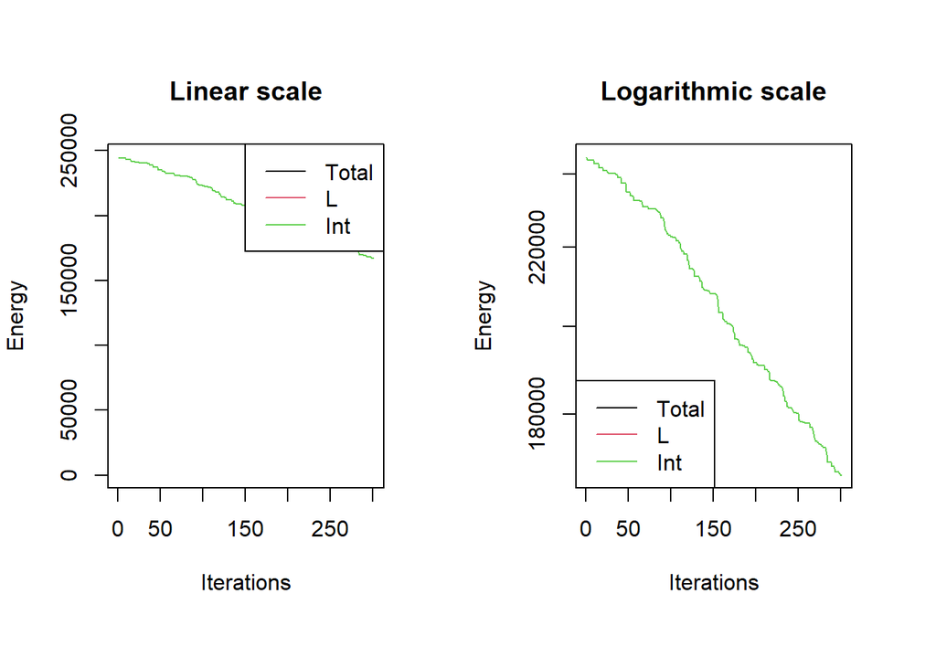

```
## +++.+...+++..+....++.+.+.+.+...+..+.+.+..++....+.+..++....+.++..++++....+.+++....+......+++.+......+(finished 400 iterations so far)
```

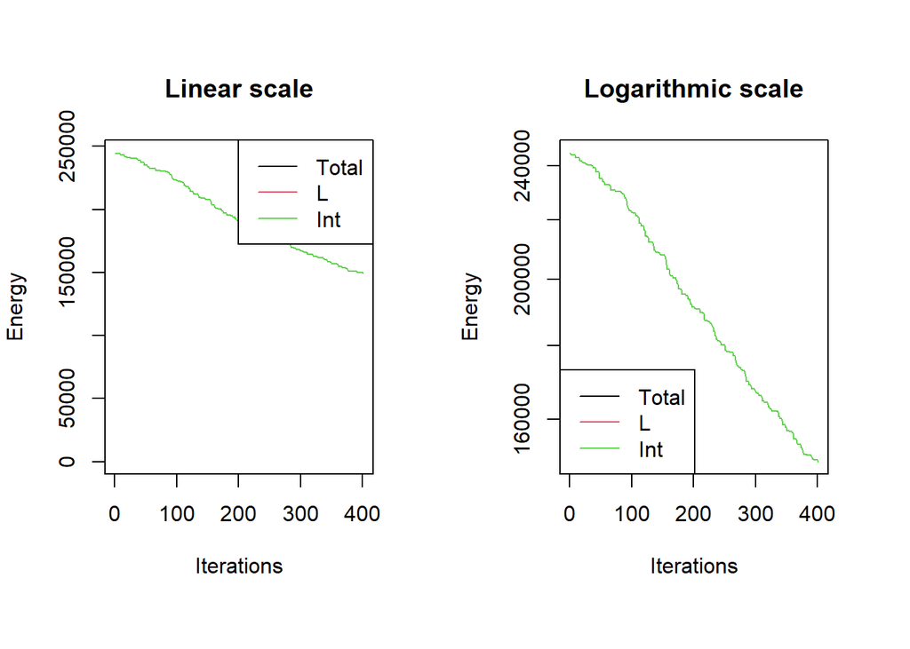

```
## +++..++.+..+.+......++.++..++..++....++.......+....+.+....+.+....+..++.++.+...+.....+...++.+...+++..(finished 500 iterations so far)
```

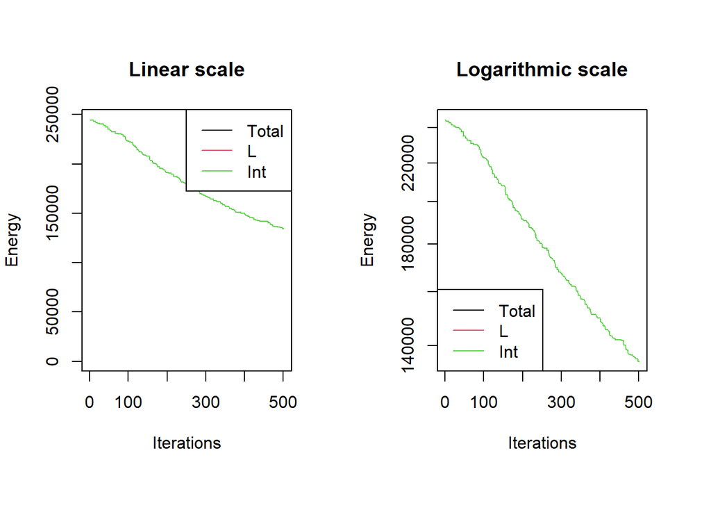

```r
L_function <- Lrt(X = spatial_data1, lambda = intensity_points,
                  Rmax = 1000000, Tmax = Tmax, grid = 32,
                  start.time = min(spatial_data1$marks),
                  end.time = max(spatial_data1$marks))

plot(L_function, type= 'l', main = "Function Lr,t)", xlab = "r (spatial)", ylab = "t (temporal)")
image.plot(L_function, main = "Function L(r,t)", xlab = "r (spatial)", ylab = "t (temporal)")

ts <-   seq(1950,2020,by=1)         # Tus categorías temporales ya codificadas como 1 a 7
Rmax <- 100000     # Límite para distancia espacial
Tmax <- 20     # Límite para distancia temporal
grid <- 32           # Resolución de la grilla

# Controles de la simulación
controls <- list(
  max.it=500,        # Número máximo de iteraciones
  max.reject = 200,    # Número máximo de rechazos
  weight.l = 0.5,        # Peso del término de la función L
  weight.int = 1e7     # Peso del término de intensidad
)

# Ejecutar la reconstrucción estocástica
res <- reconstruct.ST1(
  X = spatial_data1,
  sigma.s = sigma.s1[1],
  sigma.t = sigma.t1[1],
  ts = ts,
  start.time = min(ts),
  end.time = max(ts),
  Rmax = Rmax,
  Tmax = Tmax,
  grid = grid,
  controls = controls
)
```

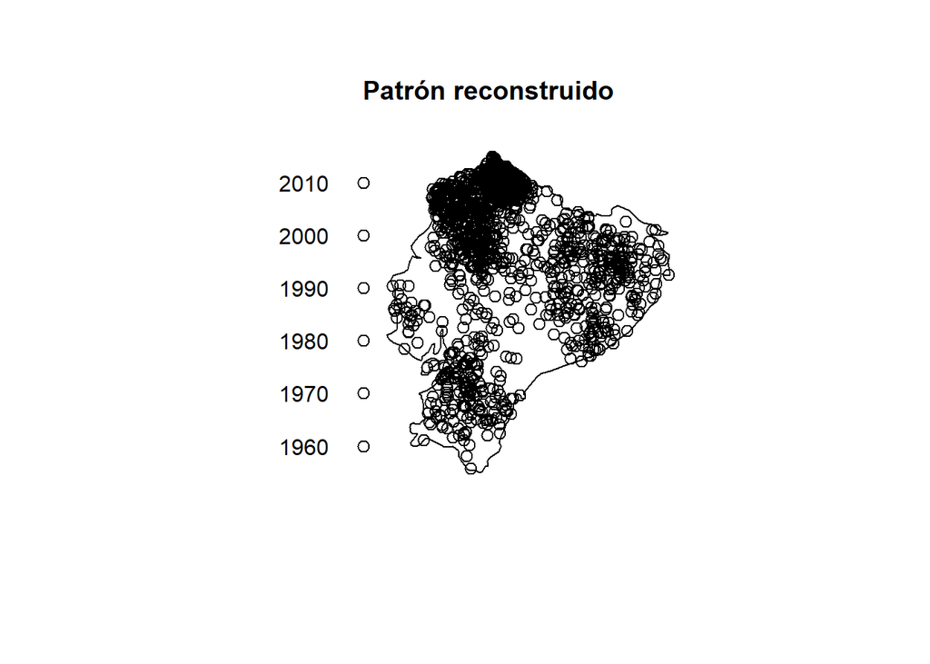

```r
# Visualizar el patrón reconstruido
par(mfrow = c(1, 1))
plot(res$Output, main = "Patrón reconstruido")
```

```r
res$Output
```

```
## Marked planar point pattern: 1525 points
## marks are numeric, of storage type  'double'
## window: polygonal boundary
## enclosing rectangle: [504137.2, 1140870.3] x [9448060, 10160976] units
```

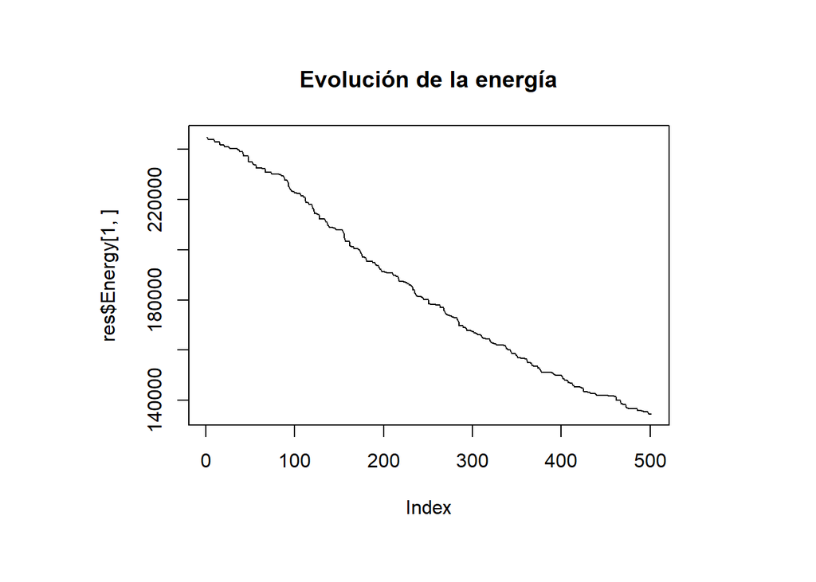

```r
# Visualizar evolución de la energía
plot(res$Energy[1,], type = "l", main = "Evolución de la energía")
```

```r
# Revisar contribuciones individuales
print(res$Elambda)
```

```
## [1] NA
```

```r
print(res$EL)
```

```
## [1] NA
```

[output not shown]